# Fordgobike Trip Data

## Invastigating Overview

These data related to some bike trips, so we want to know who spend more time in trip and does your age affect the ride also who is more subscribers or customers? These are some of the questions we will answer using visualz and charts.

## Dataset Overview

The data consisted of trips of approximately 183412 trips. They were taking during february-2019. the data has some records like the birth year, gender, start and end time, and duration of the trip

### Now, the first question will be who is the more customers or subscribers?

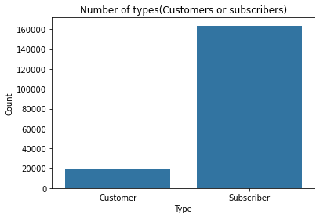

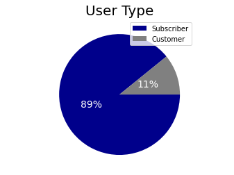

### We can see from the histogram that the subscribers is way more than the customers and its percentage about nine times the other.

### We can assume that themost people need bikes for everyday use like sports or to go to work so they subscribe.

### The second question we can ask is between the two types mentioned before who spends more in trips?

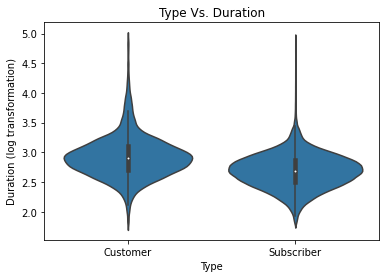

### We can see that the customer may spend more in a trip. perhaps the customer need the bike one time for a long trip but the subscriber may needed for sport or to go to work near his house so the trip is short.

### Third question we can ask is which gender rides the most?

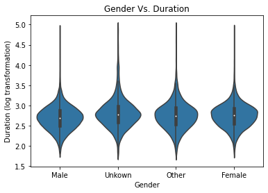

### We can see that the four curves seem to be normally distributed

- It seems like the ones who refused to declare their gender(Unknown) sometimes tend to spend more time in trips but the average of the trip is some how between 500 and 1000 seconds

### The final question is related to age, Which age do you think ride the most?

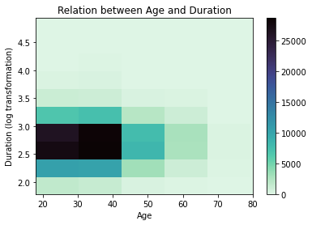

### We can see that the most duarations fall between the ages of 20 and 40 maybe becauese they are healthier

### Conclusion : After drawing some visuals we reached to these insights,

- The numbers of subscribers is much higher than the number of customers may be related for the everyday use of people so subscribtion is easier.
- All genders have approxmatily the average number of duration.
- Younger people ride more than older people maybe because they healthier.
- Subscribers have shorter trip duration than customers.

#### Must be put in mind that these insghts were based only on the data provided and data analysis techniques applied on the data.